# Taller 2 - Análisis Avanzado de Datos

Carlos Garavito y Cristhian Zamora

2023-05-05

# Análisis Avanzado de Datos - Taller 2

**Carlos Garavito y Cristhian Zamora**

El conjunto de datos Auto en la librería ISLR2, contiene la información del rendimiento y otras variables para un total de 392 vehículos. Como nos dimos cuenta, la relación entre dos de sus variables (horsepower y mpg) es resumida de manera parsimoniosa mediante un polinomio global de grado 2, sin embargo un spline suavizado (smoothing spline) parece dar un menor error de predicción. Por otra parte, determinar la ubicación y cantidad de knots en el spline de regresión (regression spline) fue un problema que desincentivó su uso. El método de validación externa utilizado para comprar los modelos fue validación regular.

## 1. Partición de los datos

Separe aleatoriamente (pero guarde la semilla) su conjunto de datos en dos partes: Entrenamiento: 90 % de los autos. Prueba: 10 % de los autos.

```r
set.seed(123) # guardar la semilla
n <- nrow(Auto)
n_entrenamiento <- round(0.9 * n) # número de observaciones en el conjunto de entrenamiento
indices_entrenamiento <- sample(1:n, n_entrenamiento, replace = FALSE)
Auto_entrenamiento <- Auto[indices_entrenamiento, ]
Auto_prueba <- Auto[-indices_entrenamiento, ]
```

## 2. Modelo spline

Usando los datos de entrenamiento Mediante validación cruzada en 10 folds, determine el número óptimo de knots para el problema de regresión spline. Considere como número de posible de knots 1,…,10, igualmente espaciados en el rango de la variable horsepower. ¿Qué modelo (es decir, cual valor de knot con k = 1, …, 10) resulta en un menor ECM de predición?

Primero, se debe ajustar un modelo de regresión lineal generalizado (GLM) con un término de regresión spline para la variable horsepower utilizando la función glm(). Para ajustar un spline, es necesario contar con una matriz de ecuaciones que se generan a través de la función bs() usando el parámetro df es posible especificar el número de grados de libertad en la función, en esta última opción, los knots se seleccionan automáticamente por R y se posicionan en cuantiles uniformes de los datos. El valor de polinomio escogido fue de 2.

```r
# Vector donde se almacenarán los errores de validación
set.seed(123)
knot_error <- rep(NA, 12)
cvspline_error <- rep(NA, 10)
auto_tr_index <- createFolds(Auto_entrenamiento$mpg, k = 10, list = TRUE, returnTrain = TRUE)
# K-fold cross validation para cada valor de df
for(i in 2:12){
  for(j in 1:10){
    entrenamiento <- Auto_entrenamiento[auto_tr_index[[j]],]
    prueba <- Auto_entrenamiento[-auto_tr_index[[j]],]

    modelo_spline <- glm(mpg ~ bs(horsepower, degree = 2, df = i),
                         data = entrenamiento)
    spline_pred <- predict(modelo_spline, newdata = prueba)
    spline_error <- mean((prueba$mpg - spline_pred )^2)
    cvspline_error[j] <- spline_error

}
set.seed(123)
knot_error[i] = mean(cvspline_error)
}
```

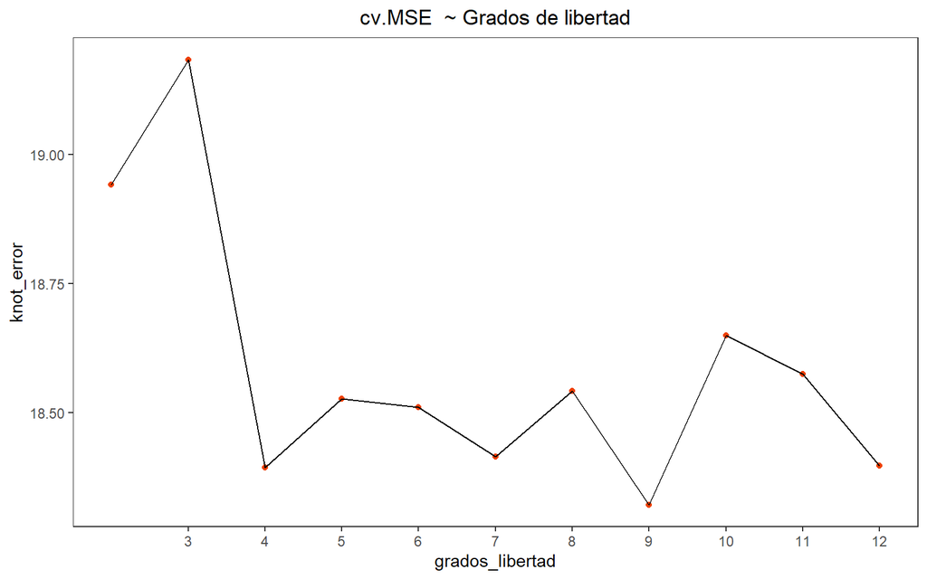

```r
ggplot(data = data.frame(grados_libertad = 2:12, knot_error = knot_error[-1]),
       aes(x = grados_libertad, y = knot_error)) +
geom_point(color = "orangered2") +
geom_path() +
scale_x_continuous(breaks=3:12) +
labs(title = "cv.MSE  ~ Grados de libertad") +
theme_bw() +
theme(panel.background = element_blank(), panel.grid.major = element_blank(), panel.grid.minor = element_blank()) +
theme(plot.title = element_text(hjust = 0.5))
```

```r
which.min(knot_error)
```

```
## [1] 9
```

```r
cat('El minimo valor de ECM es ',knot_error[9],', se consigue con ', which.min(knot_error), 'Grados de libertad')
```

```
## El minimo valor de ECM es  18.32187 , se consigue con  9 Grados de libertad
```

El valor optimo de df, que minimiza el valor del ECM, es igual a 9, lo que en este caso corresponderá a 7 knots. A continuación se presenta el número y posición de los knots en función de los df:

```r
# Número y posición de los knots en función de los df
attr(x = bs(Auto_entrenamiento$horsepower, degree = 2, df = 9), which = "knots")
```

```
## 12.5%   25% 37.5%   50% 62.5%   75% 87.5%
##    67    75    87    95   105   129   150
```

## 3. Comparación métodos de modelado

Usando los datos de entrenamiento, determine el mejor modelo basado en base de funciones Compare el poder de predicción de los modelos: polinomio grado 2 global, spline suavizado y del modelo de regresión spline óptimo (encontrado en el punto anterior) utilizando validación cruzada en 10 folds. ¿Cúal de los tres modelos seleccionaría basado en el ECM de predición?

Primero, se ajustará el modelo de polinomio global de grado 2 usando los datos de entrenamiento y evaluando sobre los datos de prueba.

```r
cvpoly_error <- rep(NA, 10)
cvsmooth_error <- rep(NA, 10)
cvspline_error <- rep(NA, 10)

for(j in 1:10){
  entrenamiento <- Auto_entrenamiento[auto_tr_index[[j]],]
  prueba <- Auto_entrenamiento[-auto_tr_index[[j]],]

  # modelo de polinomio global de grado 2
  poly_model <- lm(mpg ~ poly(horsepower, 2), data = entrenamiento)
  poly_pred <- predict(poly_model, newdata = prueba)
  poly_error <- mean((prueba$mpg - poly_pred)^2)
  cvpoly_error[j] <- poly_error
  # modelo de spline suavizado
  smooth_spline <- smooth.spline(entrenamiento$horsepower, entrenamiento$mpg, all.knots = FALSE, nknots = 10)
  smooth_pred <- predict(smooth_spline, newdata = prueba$horsepower)
  smooth_error <- mean((prueba$mpg - smooth_pred$y)^2)
  cvsmooth_error[j] <- smooth_error
  # modelo de regresion spline
  modelo_spline <- glm(mpg ~ bs(horsepower, degree = 2, df = 9),data = entrenamiento)
  spline_pred <- predict(modelo_spline, newdata = prueba)
  spline_error <- mean((prueba$mpg - spline_pred)^2)
  cvspline_error[j] <- spline_error
}
avg_poly_error <- mean(cvpoly_error)
avg_smooth_error <- mean(cvsmooth_error)
avg_spline_error <- mean(cvspline_error)

cat('El ECM promedio de la regresion polinomica de grado 2 fue: ', avg_poly_error)
```

```
## El ECM promedio de la regresion polinomica de grado 2 fue:  18.94157
```

```r
cat('El ECM promedio del modelo spline suavizado fue : ', avg_smooth_error)
```

```
## El ECM promedio del modelo spline suavizado fue :  119.5762
```

```r
cat('El ECM promedio de la regresión spline fue : ', avg_spline_error)
```

```
## El ECM promedio de la regresión spline fue :  18.32187
```

## 4. Modelo de regesión local

Usando los datos de entrenamiento, determine el mejor modelo basado en regresión local Determine la regresión polinomial local con kernel gaussiano que resulte en menor error de predicción: regresión de grado 0, 1 o 2. Use el ancho de banda óptimo dado por defecto por la función loess()

```r
cvlocal_error <- rep(NA, 10)

for(i in 0:2){
  for(j in 1:10){
    entrenamiento <- Auto_entrenamiento[auto_tr_index[[j]],]
    prueba <- Auto_entrenamiento[-auto_tr_index[[j]],]

    modelo_local <- loess(mpg ~ horsepower, degree=i,family ="gaussian", data = entrenamiento)
    local_pred <- predict(modelo_local, newdata = prueba$horsepower)
    local_error <- mean((prueba$mpg - local_pred)^2)
    cvlocal_error[j] <- local_error
  }
avg_local_error <- mean(cvlocal_error, na.rm=TRUE)

cat('Regresion de grado: ', i, 'tiene un ECM de: ', avg_local_error,"\n")

}
```

```
## Regresion de grado:  0 tiene un ECM de:  25.72606
## Regresion de grado:  1 tiene un ECM de:  17.74824
## Regresion de grado:  2 tiene un ECM de:  17.36377
```

Tal como podemos observar, la regresión de grado 2 tiene un menor ECM.

## 5. El mejor de los tres paradigmas

Usando los datos de entrenamiento y de prueba, determine el mejor de los tres paradigmas de modelamiento Ajuste el mejor modelo basado en base de funciones, el mejor modelo basado en regresión local y un polinomio global de grado dos con los datos de entrenamiento y calcule el ECM de prueba para cada modelo.

```r
# base de funciones
bases=splines::bs(Auto_entrenamiento$horsepower,
                  Boundary.knots = range(Auto_entrenamiento$horsepower)+c(-5,+5),degree=2)
model_bases <- lm(Auto_entrenamiento$mpg ~ bases)
pred_bases <- predict(model_bases, newdata=Auto_prueba)
mse_bases <- mean((Auto_prueba$mpg-pred_bases)^2)

# polinomio grado 2
modelo_local_2 <- lm(mpg ~ poly(horsepower,2),data=Auto_entrenamiento)
pred_poli <- predict(modelo_local_2, Auto_prueba)
mse_poli <- mean((Auto_prueba$mpg - pred_poli)^2)

# regresión local
smoothing = ksmooth(Auto_entrenamiento$horsepower,Auto_entrenamiento$mpg, "normal")
fit_2 = loess(mpg ~ horsepower , degree = 2, data = Auto_entrenamiento)
pred_sm <- predict(fit_2, data.frame(horsepower = smoothing$x))
mse_sm <- mean((Auto_prueba$mpg - pred_sm)^2)

cat("Funciones:",round(mse_bases,3),"\n",
    "Polinomio grado 2 global:",round(mse_poli,3),"\n",
    "Regresión local (suavizamiento kernel):",round(mse_sm,3),"\n")
```

```
## Funciones: 86.573
##  Polinomio grado 2 global: 22.174
##  Regresión local (suavizamiento kernel): 110.044
```

## 6. Experimentación y compararación

Repita (1) - (5) un total de 10 veces de manera que en el paso (1) conforme una nueva muestra de validación cruzada, esto le permitirá obtener 10 ECM de prueba para cada paradigma de modelamiento. Grafique las tres distribuciones del ECM de prueba y responda ¿Cuál acercmiento seleccionaría basado en el ECM de predición: basado en base de funciones, basado en regresión local o polinomial global?

```r
cvpoly_error <- rep(NA, 10)
cvsmooth_error <- rep(NA, 10)
cvspline_error <- rep(NA, 10)

for(i in 1:10){
  set.seed(123) # guardar la semilla
  n <- nrow(Auto)
  n_entrenamiento <- round(0.9 * n) # número de observaciones en el conjunto de entrenamiento
  indices_entrenamiento <- sample(1:n, n_entrenamiento, replace = FALSE)
  Auto_entrenamiento <- Auto[indices_entrenamiento, ]
  Auto_prueba <- Auto[-indices_entrenamiento, ]

  # modelo de polinomio global de grado 2
  poly_model <- lm(mpg ~ poly(Auto_entrenamiento$horsepower, 2), data = Auto_entrenamiento)
  poly_pred <- predict(poly_model, newdata = Auto_prueba)
  poly_error <- mean((Auto_prueba$mpg - poly_pred)^2)
  cvpoly_error[i] <- poly_error

  # modelo de spline suavizado
  smooth_spline <- smooth.spline(Auto_entrenamiento$horsepower, Auto_entrenamiento$mpg, all.knots = FALSE, nknots = 10)
  smooth_pred <- predict(smooth_spline, newdata = Auto_prueba$horsepower)
  smooth_error <- mean((Auto_prueba$mpg - smooth_pred$y)^2)
  cvsmooth_error[i] <- smooth_error

  # modelo de regresion spline
  modelo_spline <- glm(mpg ~ bs(Auto_entrenamiento$horsepower, degree = 2, df = 9),data = Auto_entrenamiento)
  spline_pred <- predict(modelo_spline, newdata = Auto_prueba)
  spline_error <- mean((Auto_prueba$mpg - spline_pred)^2)
  cvspline_error[i] <- spline_error

}

avg_poly_error <- mean(cvpoly_error)
avg_smooth_error <- mean(cvsmooth_error)
avg_spline_error <- mean(cvspline_error)

cat('El ECM promedio de la regresion polinomica de grado 2 fue: ', avg_poly_error,"\n")
```

```
## El ECM promedio de la regresion polinomica de grado 2 fue:  86.57297
```

```r
cat('El ECM promedio del modelo spline suavizado fue : ', avg_smooth_error,"\n")
```

```
## El ECM promedio del modelo spline suavizado fue :  104.0917
```

```r
cat('El ECM promedio de la regresión spline fue : ', avg_spline_error,"\n")
```

```
## El ECM promedio de la regresión spline fue :  87.80859
```

Podemos observar que el método de modelado que tiene menor ECM es la regresión polinomica de grado 2.

## 7. Estimador de Nadarya–Watson

Escriba el estimador de Nadarya–Watson para la i-ésima unidad estadística en t, es decir, x(t).

El estimador de Nadaraya-Watson es una técnica de suavizado de kernel no paramétrica que se utiliza para estimar la función de densidad o la función de regresión de una variable aleatoria. Para obtener el estimador de Nadaraya-Watson para la i-ésima unidad estadística en t, se utiliza la siguiente fórmula:

$$\begin{equation}
\hat{f}{NW,i}(t) =
\frac{\sum{j=1}^{n}K\left(\frac{t-t_j}{h}\right)x_j}{\sum_{j=1}^{n}K\left(\frac{t-t_j}{h}\right)}
\end{equation}$$

donde:

## 8. Estimador de Nadarya–Watson para la función media en t

Escriba el estimador de Nadarya–Watson para la función media en t, es decir, µ(t). Note que todos los datos discretizados son utilizados en la estimación de la función media.

El estimador de Nadarya-Watson se puede utilizar para estimar la función media µ(t) de las funciones xi en un punto de tiempo t. A diferencia del estimador anterior, en este caso se utilizan todos los datos discretizados para la estimación de la función media.

El estimador de Nadarya-Watson para la función media en t se define como sigue:

$$\begin{equation}
\hat{\mu}(t) = \frac{\sum_{i=1}^N \sum_{j=1}^{n_i}
K((t-t_{ij})/h)x_{ij}}{\sum_{i=1}^N \sum_{j=1}^{n_i} K((t-t_{ij})/h)}
\end{equation}$$

Donde:

- $\hat{\mu}(t)$ es la estimación de la función media en el punto de tiempo t.
- $K$ es una función kernel simétrica y suave, que se utiliza para dar más peso a las observaciones más cercanas a t. Ejemplos comunes de funciones kernel incluyen la función gaussiana y la función triangular.
- $h$ es el ancho de banda, que controla la anchura de la ventana utilizada para ajustar el modelo de regresión local. Un ancho de banda más pequeño da como resultado un modelo más sensible a las fluctuaciones locales, mientras que un ancho de banda más grande da como resultado un modelo más suave y global.
- $x_{ij}$ es la observación j-ésima de la i-ésima unidad estadística en el tiempo $t_{ij}$.
- $n_i$ es el número de observaciones para la i-ésima unidad estadística.
- $N$ es el número total de unidades estadísticas.

En resumen, el estimador de Nadarya-Watson para la función media en t se basa en la regresión local utilizando una función kernel simétrica y suave para estimar la función media µ(t) en ese punto de tiempo. El ancho de banda controla la sensibilidad del modelo a las fluctuaciones locales. Este estimador utiliza todos los datos discretizados para la estimación de la función media.